# BSGatlas: Merging

Adrian Geissler, Christian Anthon, Stefan Seemann and Jan Gorodkin

Center for non-coding RNA in Technology and Health, Department of Veterinary and Animal Sciences, University of Copenhagen, Denmark  
Corresponding author

2019-06-14 14:42:48

# 1 Merging

We assigned to each resource a priority, indicating how much we trust these in comparison to the other available resources. We compared each pair of genes and overlap, and computed for each overlapping pair the Jaccard similarity.

The pair of genes from RefSeq and BsubCyc that correspond to each other according to their loci identifiers are on average highly similar (Jaccard > 99%); only 11 pairs are less simililar that Jaccard < 90%, and only 5 gene pairs are less similiar than 80%.

For the used resources, we assigned the following confidence levels:

| Priority | Resource |
| --- | --- |
| 0 | Coding Genes from RefSeq |
| 1 | Coding Genes from BsubCyc |
| 2 | Non-Coding Genes from RefSeq |
| 2 | Conservative Rfam scan |
| 2 | Genes found in literature review by Nicolas et al |
| 2 | Tiling-array genes identified as trusted by Nicolas et al |
| 3 | Non-Coding Genes from BsubCyc |
| 3 | Riboswitch predictions from term-seq |
| 4 | Rfam scan with medium sensetive parameters |
| 4 | Genes found by the tiling array study |

With respect to all resources, a histogram of these similarities with clear indication resources priority the genes in the overlapping pair are is shown in:

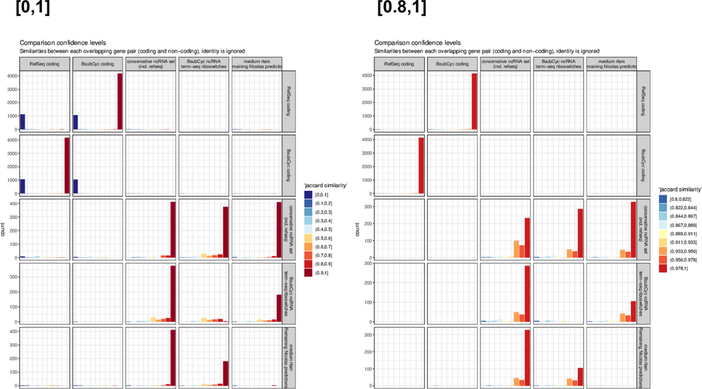

These distirbution shows that nearly all overlaps between coding genes are either very similiar (Jaccard > 97.8%) or very dissimilar (< 10%). The ncRNA genes tend to either overlap with a high similarity (> 90%) or not at all, a pattern persistent across all different level of priorities. There is only a single pair of a low confidence, putative ncRNA and a coding gene. Therefore, we assume that two genes with a similarity above 80% are identical. This cut-off is slightly lower than the observed trends, such that the overall sensetivity is larger and most corresponding pairs of genes between RefSeq and BsubCyc are included. Upon closer investigation of the RNA annotation, decided to further relax the condition to account for the overall lower quality. Thus, the relaxed identity exludes overlap between riboswitches and coding sequences, assumes a Jaccard similarity of at least 80%, or for overlaps between to RNA genes/structures of at least 50% or the special cased that one annotation is fully contained within the other. (Containment rule only for RNAs)

with the exception of riboswitches that overlap known coding sequences. These are kept separate.

We identified all pairs of genes that fullfill this identity criteria. Using the concept of transitivity, we select groups of genes that are identical via computation of components in a graph. For each group, we collect the coordinates from the resource from the highest priority, or the union if there are multiple genes of equal priority. The outline for this approach is:

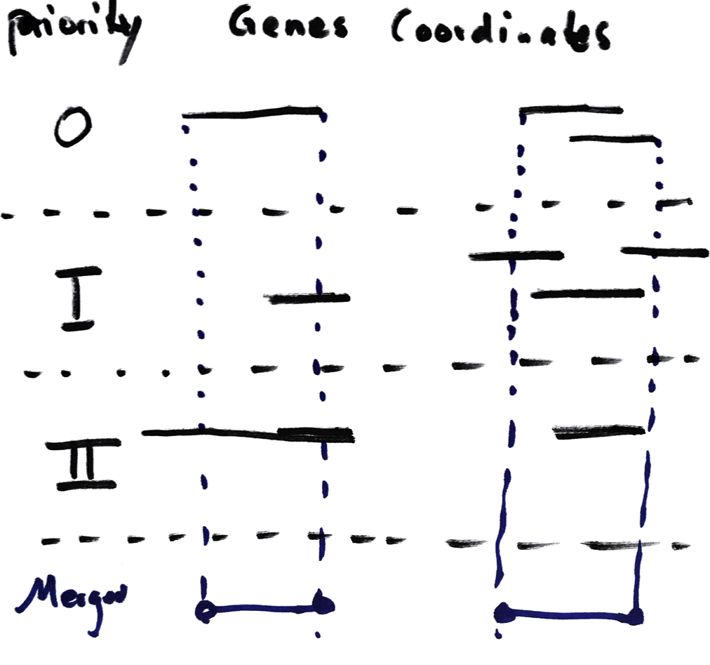

Afterwards, we found for each group the most specific type description across all priorities. In most cases, these are the type which is not putative. In only few cases we resolved ambiguioty by prefering the type description asRNA over sRNA, and sRNA over riboswitch. The latter ambiguoity comes from the term-seq resource, which did not investigate possible additional biological functions of partially transcribed RNAs.

For all resources, the merging statistics are

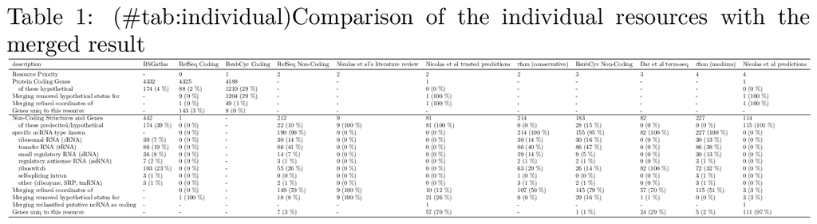

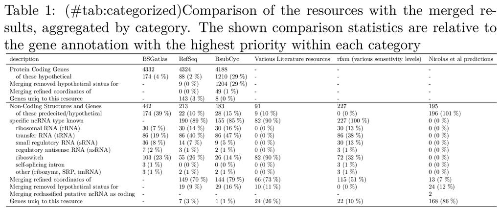